# تمرین سری دوم

Mohammad Mehdi Zare

2023-06-16

در این تمرین هدف ما کار کردن با دیتای مربوط به دیتابت است که توسط نظرسنجی BRFSS بدست امده و شامل 441455 نمونه و 330 فیچر است . اما دیتایی که ما با ان کار میکنیم دیتای تمیز شده است که شامل 70692 نمونه و 21 فیچر است . در این تمرین تصمیم گرفتم که فقط از دیتای متوازن استفاده کنم, چرا که دیتای نامتوازن در اموزش مدل باعث بایاس در مدل میشود .

در تمرین از کتابخانه های زیر استفاده شده است

#install packages

```r
library(ggcorrplot)
library(data.table)
library(ggplot2)
library(naivebayes)
library(class)
library(tidyverse)
library(caret)
library(leaps)
library(MASS)
library(randomForest)

library(lemon)
knit_print.data.frame <- lemon_print
```

حال در ابتدا دیتا را بررسی میکنیم و با فیچر ها و … اشنا میشویم

```r
df=fread("C:/Users/Mehdi/Documents/R/workspace/diabetes_binary_5050split_health_indicators_BRFSS2015.csv")

print(names(df))
```

```
##  [1] "Diabetes_binary"      "HighBP"               "HighChol"
##  [4] "CholCheck"            "BMI"                  "Smoker"
##  [7] "Stroke"               "HeartDiseaseorAttack" "PhysActivity"
## [10] "Fruits"               "Veggies"              "HvyAlcoholConsump"
## [13] "AnyHealthcare"        "NoDocbcCost"          "GenHlth"
## [16] "MentHlth"             "PhysHlth"             "DiffWalk"
## [19] "Sex"                  "Age"                  "Education"
## [22] "Income"
```

```r
print(sapply(df,class))
```

```
##      Diabetes_binary               HighBP             HighChol
##            "numeric"            "numeric"            "numeric"
##            CholCheck                  BMI               Smoker
##            "numeric"            "numeric"            "numeric"
##               Stroke HeartDiseaseorAttack         PhysActivity
##            "numeric"            "numeric"            "numeric"
##               Fruits              Veggies    HvyAlcoholConsump
##            "numeric"            "numeric"            "numeric"
##        AnyHealthcare          NoDocbcCost              GenHlth
##            "numeric"            "numeric"            "numeric"
##             MentHlth             PhysHlth             DiffWalk
##            "numeric"            "numeric"            "numeric"
##                  Sex                  Age            Education
##            "numeric"            "numeric"            "numeric"
##               Income
##            "numeric"
```

```r
print(summary(df))
```

```
##  Diabetes_binary     HighBP          HighChol        CholCheck
##  Min.   :0.0     Min.   :0.0000   Min.   :0.0000   Min.   :0.0000
##  1st Qu.:0.0     1st Qu.:0.0000   1st Qu.:0.0000   1st Qu.:1.0000
##  Median :0.5     Median :1.0000   Median :1.0000   Median :1.0000
##  Mean   :0.5     Mean   :0.5635   Mean   :0.5257   Mean   :0.9753
##  3rd Qu.:1.0     3rd Qu.:1.0000   3rd Qu.:1.0000   3rd Qu.:1.0000
##  Max.   :1.0     Max.   :1.0000   Max.   :1.0000   Max.   :1.0000
##       BMI            Smoker           Stroke        HeartDiseaseorAttack
##  Min.   :12.00   Min.   :0.0000   Min.   :0.00000   Min.   :0.0000
##  1st Qu.:25.00   1st Qu.:0.0000   1st Qu.:0.00000   1st Qu.:0.0000
##  Median :29.00   Median :0.0000   Median :0.00000   Median :0.0000
##  Mean   :29.86   Mean   :0.4753   Mean   :0.06217   Mean   :0.1478
##  3rd Qu.:33.00   3rd Qu.:1.0000   3rd Qu.:0.00000   3rd Qu.:0.0000
##  Max.   :98.00   Max.   :1.0000   Max.   :1.00000   Max.   :1.0000
##   PhysActivity       Fruits          Veggies       HvyAlcoholConsump
##  Min.   :0.000   Min.   :0.0000   Min.   :0.0000   Min.   :0.00000
##  1st Qu.:0.000   1st Qu.:0.0000   1st Qu.:1.0000   1st Qu.:0.00000
##  Median :1.000   Median :1.0000   Median :1.0000   Median :0.00000
##  Mean   :0.703   Mean   :0.6118   Mean   :0.7888   Mean   :0.04272
##  3rd Qu.:1.000   3rd Qu.:1.0000   3rd Qu.:1.0000   3rd Qu.:0.00000
##  Max.   :1.000   Max.   :1.0000   Max.   :1.0000   Max.   :1.00000
##  AnyHealthcare    NoDocbcCost         GenHlth         MentHlth
##  Min.   :0.000   Min.   :0.00000   Min.   :1.000   Min.   : 0.000
##  1st Qu.:1.000   1st Qu.:0.00000   1st Qu.:2.000   1st Qu.: 0.000
##  Median :1.000   Median :0.00000   Median :3.000   Median : 0.000
##  Mean   :0.955   Mean   :0.09391   Mean   :2.837   Mean   : 3.752
##  3rd Qu.:1.000   3rd Qu.:0.00000   3rd Qu.:4.000   3rd Qu.: 2.000
##  Max.   :1.000   Max.   :1.00000   Max.   :5.000   Max.   :30.000
##     PhysHlth        DiffWalk           Sex             Age
##  Min.   : 0.00   Min.   :0.0000   Min.   :0.000   Min.   : 1.000
##  1st Qu.: 0.00   1st Qu.:0.0000   1st Qu.:0.000   1st Qu.: 7.000
##  Median : 0.00   Median :0.0000   Median :0.000   Median : 9.000
##  Mean   : 5.81   Mean   :0.2527   Mean   :0.457   Mean   : 8.584
##  3rd Qu.: 6.00   3rd Qu.:1.0000   3rd Qu.:1.000   3rd Qu.:11.000
##  Max.   :30.00   Max.   :1.0000   Max.   :1.000   Max.   :13.000
##    Education         Income
##  Min.   :1.000   Min.   :1.000
##  1st Qu.:4.000   1st Qu.:4.000
##  Median :5.000   Median :6.000
##  Mean   :4.921   Mean   :5.698
##  3rd Qu.:6.000   3rd Qu.:8.000
##  Max.   :6.000   Max.   :8.000
```

برای تفسیر پذیری و راحتی کار مقادیر هر فیجر را با کلمات دیگری جایگزین میکنیم.مثلا ستون diabetes_binary را به صورت yes , no در می اوریم.

```r
d=copy(df)

d$Diabetes_binary[d$Diabetes_binary==0 ]<-"no"
d$Diabetes_binary[d$Diabetes_binary==1 ]<-"yes"
d$Sex[d$Sex==0 ]<-"female"
d$Sex[d$Sex==1 ]<-"male"
d$HighChol[d$HighChol==0 ]<-"no"
d$HighChol[d$HighChol==1 ]<-"yes"
d$Smoker[d$Smoker==0 ]<-"no"
d$Smoker[d$Smoker==1 ]<-"yes"
```

## Problem 1

پرسش اول : برای پاسخ به پرسش اول سعی میکنیم رابطه فیچر های مختلف با دیابت را ببینم . برای اینکار از نمودار های مختلفی مثل نمودار جعبه و توزیع چگالی و هیستوگرام و … کمک میگیریم .

ابتدا ماتریس همبستگی را رسم میکنیم

```r
correlation_matrix <- cor(df)
correlation_matrix
```

```
##                      Diabetes_binary      HighBP    HighChol     CholCheck
## Diabetes_binary           1.00000000  0.38151555  0.28921281  0.1153816171
## HighBP                    0.38151555  1.00000000  0.31651485  0.1032832913
## HighChol                  0.28921281  0.31651485  1.00000000  0.0859813978
## CholCheck                 0.11538162  0.10328329  0.08598140  1.0000000000
## BMI                       0.29337274  0.24101856  0.13130949  0.0456475209
## Smoker                    0.08599896  0.08743830  0.09339831 -0.0043305151
## Stroke                    0.12542678  0.12905987  0.09978619  0.0225293810
## HeartDiseaseorAttack      0.21152340  0.21075039  0.18118664  0.0434971444
## PhysActivity             -0.15866560 -0.13610217 -0.09045316 -0.0082493633
## Fruits                   -0.05407656 -0.04085216 -0.04738362  0.0173838322
## Veggies                  -0.07929315 -0.06662374 -0.04283626  0.0003492577
## HvyAlcoholConsump        -0.09485314 -0.02702989 -0.02544298 -0.0271461602
## AnyHealthcare             0.02319075  0.03576444  0.03153180  0.1068004249
## NoDocbcCost               0.04097657  0.02651701  0.03319927 -0.0626687433
## GenHlth                   0.40761160  0.32053981  0.23777820  0.0592134125
## MentHlth                  0.08702877  0.06429371  0.08388071 -0.0106602375
## PhysHlth                  0.21308102  0.17392173  0.14261035  0.0345401017
## DiffWalk                  0.27264601  0.23478391  0.16204341  0.0444303666
## Sex                       0.04441286  0.04081925  0.01732446 -0.0079912226
## Age                       0.27873807  0.33813193  0.24033775  0.1017432891
## Education                -0.17048063 -0.14164264 -0.08438612 -0.0086948352
## Income                   -0.22444871 -0.18765683 -0.10777657  0.0075504178
##                               BMI       Smoker       Stroke
## Diabetes_binary       0.293372745  0.085998964  0.125426785
## HighBP                0.241018561  0.087438297  0.129059872
## HighChol              0.131309487  0.093398312  0.099786191
## CholCheck             0.045647521 -0.004330515  0.022529381
## BMI                   1.000000000  0.011551350  0.022930877
## Smoker                0.011551350  1.000000000  0.064658397
## Stroke                0.022930877  0.064658397  1.000000000
## HeartDiseaseorAttack  0.060354865  0.124417535  0.223393786
## PhysActivity         -0.170936077 -0.079823258 -0.079984782
## Fruits               -0.084505333 -0.074810805 -0.008996297
## Veggies              -0.056527598 -0.029925651 -0.047601204
## HvyAlcoholConsump    -0.058231697  0.077835011 -0.023394552
## AnyHealthcare        -0.013417050 -0.012938633  0.006483591
## NoDocbcCost           0.065831621  0.035798890  0.036198325
## GenHlth               0.267887547  0.152416015  0.189446857
## MentHlth              0.104681505  0.091256623  0.087303439
```

[output cut: 83 more lines]

```
## HeartDiseaseorAttack  0.098161367  0.221877780 -0.096558736 -0.146748413
## PhysActivity          0.051752891 -0.100752963  0.190271208  0.196551353
## Fruits               -0.088723101  0.061095654  0.098714685  0.079009161
## Veggies              -0.052603777 -0.018893425  0.152511898  0.154898762
## HvyAlcoholConsump     0.014164398 -0.057705293  0.036279476  0.064095269
## AnyHealthcare        -0.006561785  0.136974925  0.106600752  0.130491525
## NoDocbcCost          -0.048186618 -0.129839183 -0.096988754 -0.198171295
## GenHlth              -0.014555307  0.155624332 -0.285420312 -0.382969385
## MentHlth             -0.089204159 -0.101746035 -0.107005084 -0.219069532
## PhysHlth             -0.045956764  0.084851718 -0.159316811 -0.279325669
## DiffWalk             -0.082248325  0.195264987 -0.202589922 -0.343245002
## Sex                   1.000000000 -0.002314598  0.043563652  0.159654284
## Age                  -0.002314598  1.000000000 -0.107127338 -0.130139619
## Education             0.043563652 -0.107127338  1.000000000  0.460565473
## Income                0.159654284 -0.130139619  0.460565473  1.000000000
```

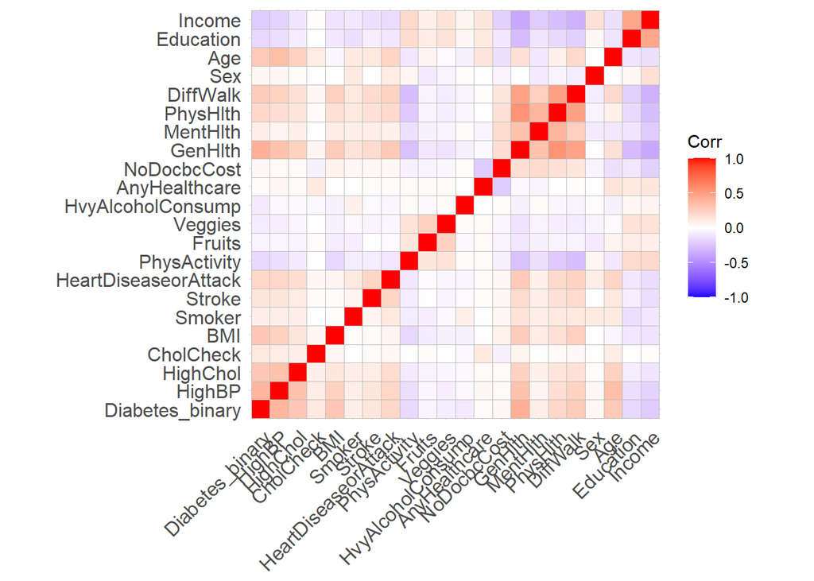

```r
ggcorrplot(correlation_matrix)
```

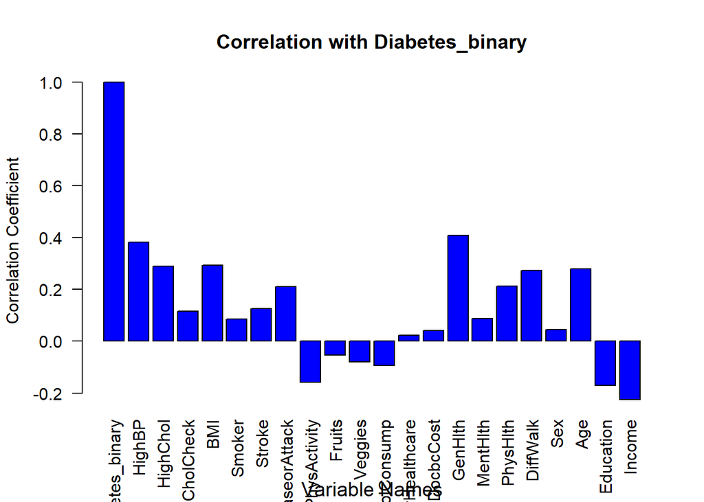

```r
#bar plot

barplot(correlation_matrix[1,], col = "blue",
  names.arg = colnames(correlation_matrix),
  main = "Correlation with Diabetes_binary",
  #xlab = "Variable Names",
  ylab = "Correlation Coefficient",
  las=2)
par(xpd=TRUE)
mtext("Variable Names", side=1, line=4, cex=1.2)
```

با توجه به ماتریس همبستگی حدس میزنیم که bmi و HighChol و Age با دیابت در ارتباط است . پس فقط همین موارد را بررسی میکنیم. اگر این موارد تاثیری در دیابت داشته باشند, پس میتوان مدلی برای پیشبینی از دیابت از روی دیتا بدست اورد و همچنین فیچر هایی مثل fruit و Smoker, sex تاثیری در دیابت ندارن .

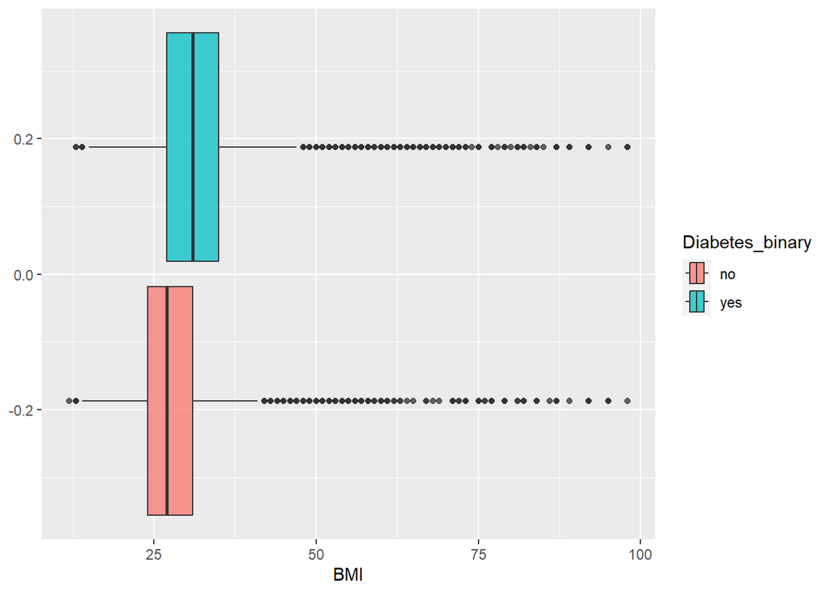

```r
#bmi
ggplot(d, aes(BMI, fill = Diabetes_binary))+
  geom_boxplot(alpha = .75)
```

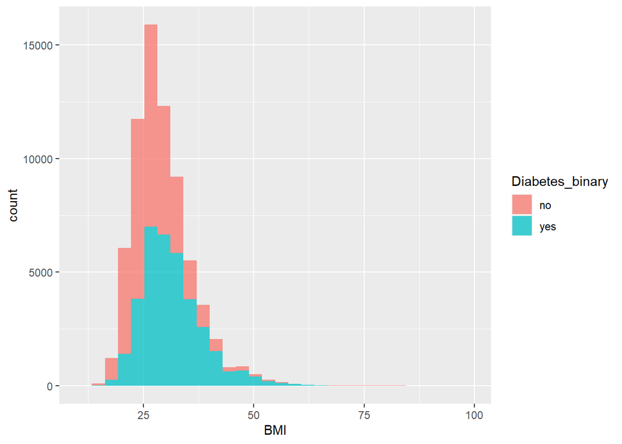

```r
ggplot(d, aes(BMI, fill = Diabetes_binary))+
  geom_histogram(alpha = .75)
```

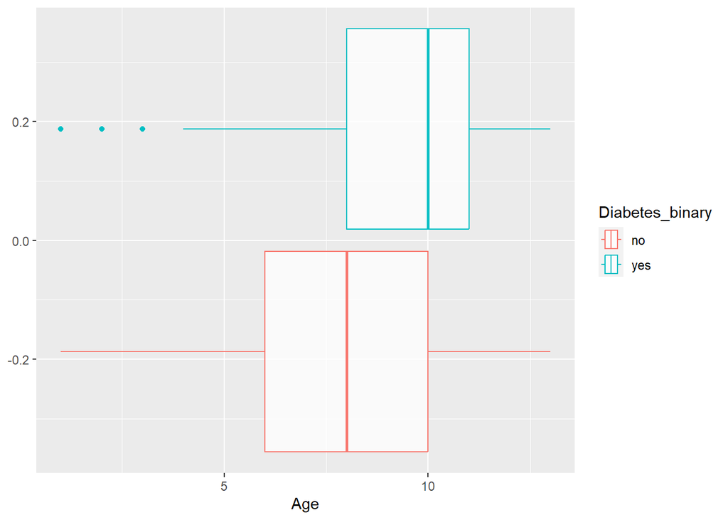

```r
#  facet_grid(Diabetes_binary ~ ., scales = 'free_y')

# age
ggplot(d, aes(Age, group = Diabetes_binary, color = Diabetes_binary))+
  geom_boxplot(alpha = .75)
```

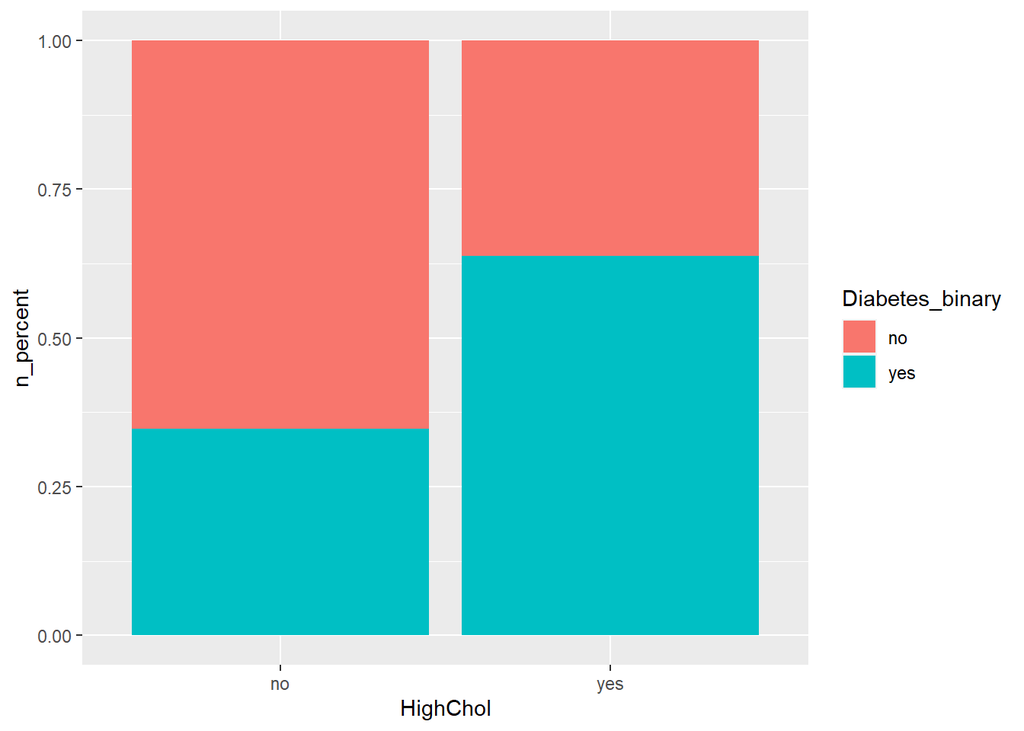

```r
# highchol

ds = d[, .(n = .N), .(Diabetes_binary, HighChol)]
ds[, n_total := sum(n), .(HighChol)]
ds[, n_percent := n / n_total]

ggplot(ds, aes(HighChol, n_percent, fill = Diabetes_binary))+
  geom_bar(stat = 'identity', )
```

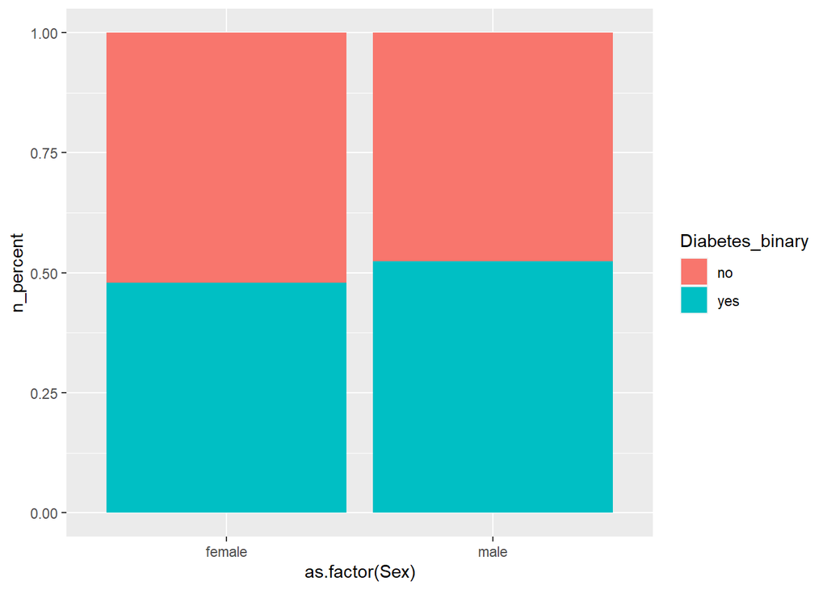

```r
# Sex

ds = d[, .(n = .N), .(Diabetes_binary, Sex)]
ds[, n_total := sum(n), .(Sex)]
ds[, n_percent := n / n_total]

ggplot(ds,
       aes(as.factor(Sex), n_percent, fill = Diabetes_binary))+
  geom_bar(stat = 'identity', )
```

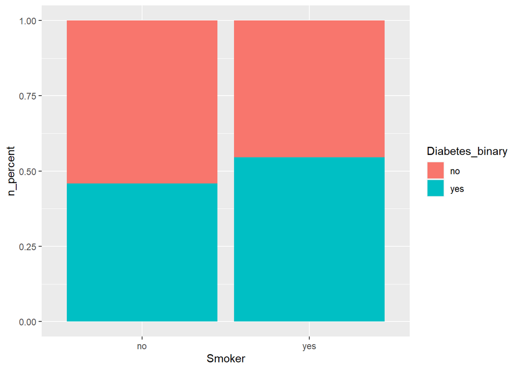

```r
# smoker
ds = d[, .(n = .N), .(Diabetes_binary, Smoker)]
ds[, n_total := sum(n), .(Smoker)]
ds[, n_percent := n / n_total]

ggplot(ds,
       aes(Smoker, n_percent, fill = Diabetes_binary))+
  geom_bar(stat = 'identity', )
```

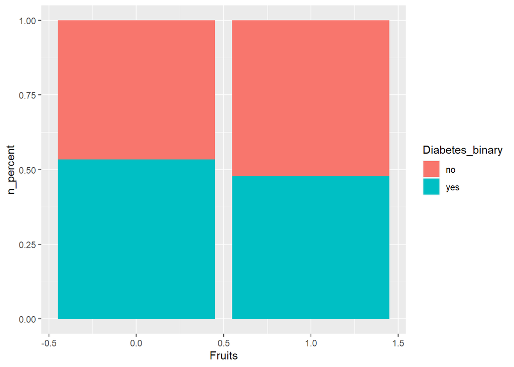

```r
#fruits
ds = d[, .(n = .N), .(Diabetes_binary, Fruits)]
ds[, n_total := sum(n), .(Fruits)]
ds[, n_percent := n / n_total]

ggplot(ds,
       aes(Fruits, n_percent, fill = Diabetes_binary))+
  geom_bar(stat = 'identity', )
```

با توجه به نمودار های بالا به خوبی میبینم که عواملی هستند که با دیابت رابطه دارن و میتوان از روی انها دیابت را پیشبینی کرد مثلا بالابودن bmi و سن و کلسترول و . البته ویژگی هایی نیز هستند که تاثیر چندانی ندارند مثل جنسیت و مصرف میوه و مصرف سیگار . اما به طور کلی و با توجه به نمودار های بالا میتوان گفت که پرسشنامه میتواند پیش‌بینی قابل قبولی از اینکه یک فرد دیابت دارد یا نه، ارائه ‌کند چزا که ویژگی هایی هستند که با دیابت همبسنگی دارند. .

## Problem 2 ,3

حالا پاسخ پرسش دوم را میدهیم :

```r
sample <- sample(c(TRUE,FALSE), nrow(df), replace=TRUE, prob=c(0.7,0.3))
  train_dataset  <- df[sample, ]
test_dataset  <- df[!sample, ]


fullModel = glm(Diabetes_binary ~ ., family = 'binomial', data = train_dataset)
nullModel = glm(Diabetes_binary ~ 1, family = 'binomial', data = train_dataset)
model<- stepAIC(nullModel,
                direction = 'both',scope = list(upper = fullModel,
                             lower = nullModel),trace = 0)

summary(model)
```

```
##
## Call:
## glm(formula = Diabetes_binary ~ GenHlth + HighBP + BMI + Age +
##     HighChol + HvyAlcoholConsump + CholCheck + Income + Sex +
##     HeartDiseaseorAttack + PhysHlth + DiffWalk + Fruits + Stroke +
##     Education + MentHlth + Veggies, family = "binomial", data = train_dataset)
##
## Deviance Residuals:
##     Min       1Q   Median       3Q      Max
## -3.5485  -0.8082  -0.1279   0.8405   2.9726
##
## Coefficients:
##                       Estimate Std. Error z value Pr(>|z|)
## (Intercept)          -6.724107   0.139115 -48.335  < 2e-16 ***
## GenHlth               0.579208   0.013577  42.660  < 2e-16 ***
## HighBP                0.736403   0.023598  31.206  < 2e-16 ***
## BMI                   0.075392   0.001867  40.379  < 2e-16 ***
## Age                   0.149334   0.004570  32.674  < 2e-16 ***
## HighChol              0.585678   0.022491  26.040  < 2e-16 ***
## HvyAlcoholConsump    -0.790053   0.058014 -13.618  < 2e-16 ***
## CholCheck             1.291625   0.093971  13.745  < 2e-16 ***
## Income               -0.057247   0.006125  -9.346  < 2e-16 ***
## Sex                   0.238886   0.022658  10.543  < 2e-16 ***
## HeartDiseaseorAttack  0.270732   0.033813   8.007 1.18e-15 ***
## PhysHlth             -0.008520   0.001414  -6.025 1.70e-09 ***
## DiffWalk              0.125572   0.030636   4.099 4.15e-05 ***
## Fruits               -0.083750   0.023257  -3.601 0.000317 ***
## Stroke                0.159858   0.048218   3.315 0.000915 ***
## Education            -0.033697   0.012078  -2.790 0.005271 **
## MentHlth             -0.002917   0.001523  -1.915 0.055540 .
## Veggies              -0.042857   0.027737  -1.545 0.122320
## ---
## Signif. codes:  0 '***' 0.001 '**' 0.01 '*' 0.05 '.' 0.1 ' ' 1
##
## (Dispersion parameter for binomial family taken to be 1)
##
##     Null deviance: 68559  on 49454  degrees of freedom
## Residual deviance: 50758  on 49437  degrees of freedom
## AIC: 50794
##
## Number of Fisher Scoring iterations: 5
```

```r
train_dataset$Diabetes_binary <- as.factor(train_dataset$Diabetes_binary)

forestmodel<-randomForest(Diabetes_binary~., data=train_dataset,
                          ntree=100 , nodesize=2,mtry= sqrt(ncol(train_dataset)), parallel= TRUE)
importance(forestmodel)
```

```
##                      MeanDecreaseGini
## HighBP                      2045.5986
## HighChol                     962.0785
## CholCheck                    129.8242
## BMI                         3203.1514
## Smoker                       528.9189
## Stroke                       218.0782
## HeartDiseaseorAttack         408.8870
## PhysActivity                 462.9999
## Fruits                       528.7885
## Veggies                      443.5974
## HvyAlcoholConsump            214.8749
## AnyHealthcare                172.0807
## NoDocbcCost                  249.8944
## GenHlth                     2470.0473
## MentHlth                    1048.9295
## PhysHlth                    1368.8872
## DiffWalk                     569.6247
## Sex                          512.3874
## Age                         2381.3785
## Education                   1062.3361
## Income                      1587.6876
```

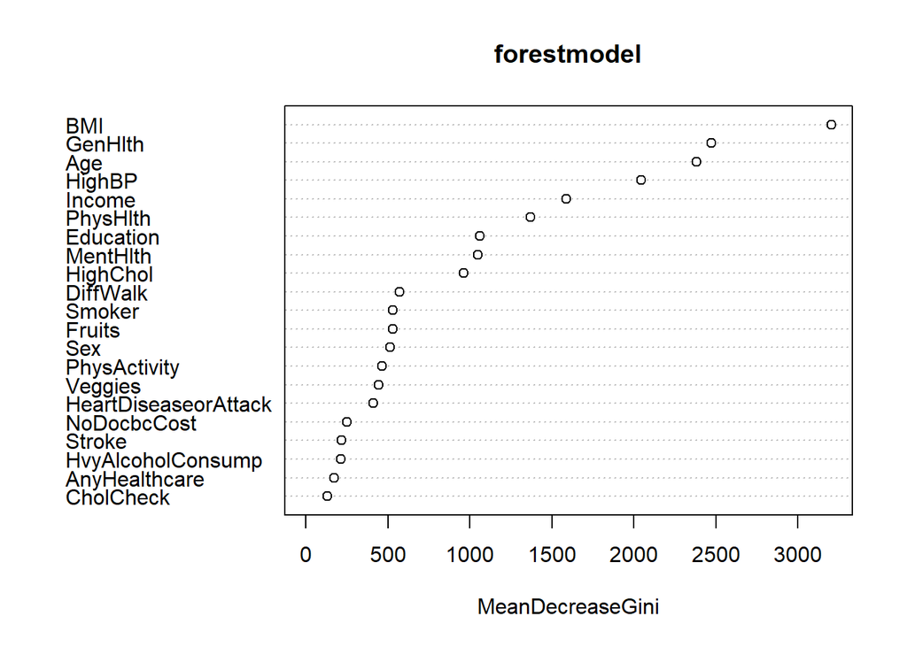

```r
varImpPlot(forestmodel)
```

```r
pred_test <- predict(forestmodel, newdata = test_dataset, type= "class")
randomForestCM=table(pred_test,test_dataset$Diabetes_binary);
confusionMatrix(randomForestCM)
```

```
## Confusion Matrix and Statistics
##
##
## pred_test    0    1
##         0 7895 2790
##         1 2711 7841
##
##                Accuracy : 0.741
##                  95% CI : (0.735, 0.7469)
##     No Information Rate : 0.5006
##     P-Value [Acc > NIR] : <2e-16
##
##                   Kappa : 0.4819
##
##  Mcnemar's Test P-Value : 0.293
##
##             Sensitivity : 0.7444
##             Specificity : 0.7376
##          Pos Pred Value : 0.7389
##          Neg Pred Value : 0.7431
##              Prevalence : 0.4994
##          Detection Rate : 0.3718
##    Detection Prevalence : 0.5031
##       Balanced Accuracy : 0.7410
##
##        'Positive' Class : 0
##
```

پاسخ سوال سوم هم همراه سوال دوم دادیم . با روش stepwise از بین فیچر ها تعدادی را انتخاب کردیم و مدل نهایی را روی انها اموزش میدهیم. و میبینیم که دقت خوبی نیز دارد. در کد پایین مدل قسمت قبل را روی داده تست , ازمایش میکنیم و دقت ان برابر با 75 درصد است.

```r
probabilities <- model %>% predict(test_dataset, type = "response")
predicted.classes <- ifelse(probabilities > 0.5, 1, 0)
print(mean(predicted.classes==test_dataset$Diabetes_binary))
```

```
## [1] 0.7496351
```

```r
library(pROC)
roc_score=roc(test_dataset$Diabetes_binary, predicted.classes)
```

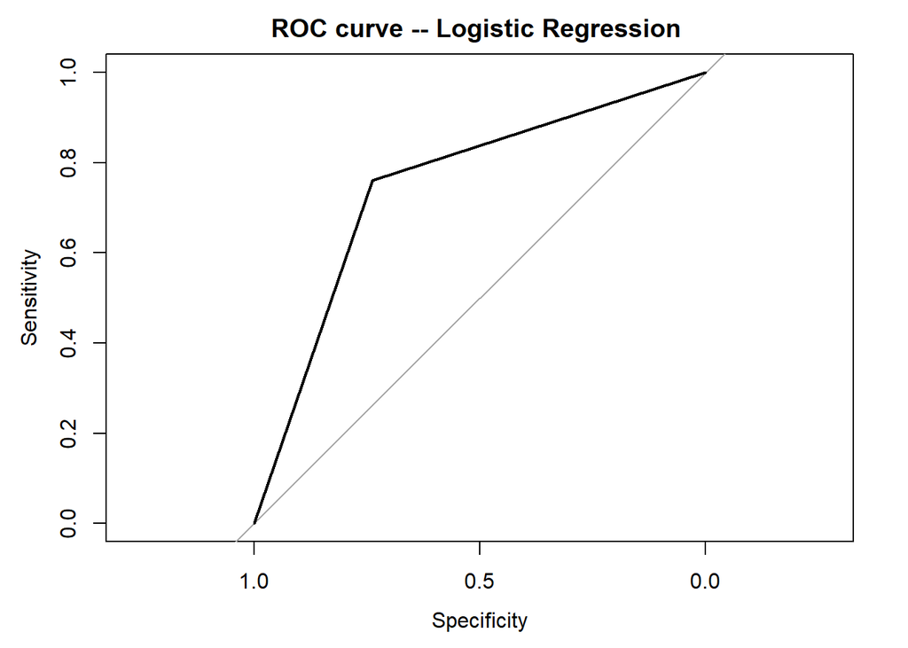

```r
plot(roc_score ,main ="ROC curve -- Logistic Regression ")
```

## Problem 4 پاسخ سوال چهارم :

متغییر های استفاده شده :

```r
print(names(unlist(model[[1]])))
```

```
##  [1] "(Intercept)"          "GenHlth"              "HighBP"
##  [4] "BMI"                  "Age"                  "HighChol"
##  [7] "HvyAlcoholConsump"    "CholCheck"            "Income"
## [10] "Sex"                  "HeartDiseaseorAttack" "PhysHlth"
## [13] "DiffWalk"             "Fruits"               "Stroke"
## [16] "Education"            "MentHlth"             "Veggies"
```

## Problem 5

```r
forestmodel<-randomForest(Diabetes_binary~BMI+Age+GenHlth+HighBP+Stroke+HighChol, data=train_dataset,
                          ntree=100 , nodesize=2,mtry= sqrt(ncol(train_dataset)), parallel= TRUE)

pred_test <- predict(forestmodel, newdata = test_dataset, type= "class")
randomForestCM=table(pred_test,test_dataset$Diabetes_binary);
confusionMatrix(randomForestCM)
```

```
## Confusion Matrix and Statistics
##
##
## pred_test    0    1
##         0 7685 2922
##         1 2921 7709
##
##                Accuracy : 0.7249
##                  95% CI : (0.7188, 0.7309)
##     No Information Rate : 0.5006
##     P-Value [Acc > NIR] : <2e-16
##
##                   Kappa : 0.4497
##
##  Mcnemar's Test P-Value : 1
##
##             Sensitivity : 0.7246
##             Specificity : 0.7251
##          Pos Pred Value : 0.7245
##          Neg Pred Value : 0.7252
##              Prevalence : 0.4994
##          Detection Rate : 0.3619
##    Detection Prevalence : 0.4995
##       Balanced Accuracy : 0.7249
##
##        'Positive' Class : 0
##
```